# Machine Learning Project

Carlos Ramirez

May 24, 2018

## **Intro**

The aim of this project was to implement a machine learning technique to predict how well an exercise activity is performed. Details of the data set can be found [here](http://web.archive.org/web/20161224072740/http:/groupware.les.inf.puc-rio.br/har).

## **Data preprocessing**

First, the training [data](https://d396qusza40orc.cloudfront.net/predmachlearn/pml-training.csv) was processed and normalized. Since the implementation was focused on accelerometer numeric values categorical and non-sense variables such as time and user names were dropped. Additionally, column variables with too many NA values (2/3 of the total) and incomplete observations were left apart. Finally, the resulting data was normalized as can be shown next.

```r
library(caret)
library(dplyr)
library(parallel)
library(doParallel)

## Data preprocessing

## loading train data
trainURL <- "https://d396qusza40orc.cloudfront.net/predmachlearn/pml-training.csv"
train <- read.csv(trainURL,colClasses = "character")

processData <- function(data) {
        ## casting data to numeric
        for (i in 1:(ncol(data)-1)) {
                data[,i] <- as.numeric(data[,i])
        }

        ## number of NA values for each variable
        NA_number <- sapply(data,function(x) length(which(is.na(x))))

        ## variables containing too many NA values are allmost constant
        ## hence they could be drop
        ## dropping variables with more than 2/3 of the number of training observations
        drop_vars <- names(data)[NA_number > (2*ncol(data))/3]

        ## removing non sense variables as name of the activity subject
        drop_vars <- c(drop_vars,
                       "X","user_name","raw_timestamp_part_1",
                       "raw_timestamp_part_2","cvtd_timestamp",
                       "kurtosis_yaw_belt","skewness_yaw_belt",
                       "kurtosis_yaw_dumbbell","amplitude_yaw_dumbbell",
                       "skewness_yaw_dumbbell","amplitude_yaw_belt",
                       "new_window","num_window")
        data.processed <- data[,!colnames(data)%in%drop_vars]
        #str(data[,colnames(data)%in%drop_vars])

        data.processed <- mutate(data.processed,classe=as.factor(classe))

        ## droping NA cases
        data.processed <- data.processed[complete.cases(data.processed),]

        ## dimension of resulting processed data
        dim(data.processed)

        ## normalizing data
        data.stand <- scale(select(data.processed,-classe))
        data.stand <- data.frame(cbind(classe=data.processed$classe,as.data.frame(data.stand)))

        return(data.stand)
}

train.stand <- processData(train)
```

The resulting processed data has 19622 rows and 53 columns of numeric real values. Then, a random forest approach was performed on this processed data. Train and test set were defined as 80 and 20 percent of the total of processed observations, respectively. A 5-fold cross validation was performed and the number of trees was setted to 45 as shown in the next code.

```r
set.seed(333)

## performing random forest
train <- createDataPartition(train.stand$classe,
                             p = 0.8,
                             list = FALSE)
#tail(train)

fitControl <- trainControl(method = "cv",
                           number = 5)
initialTime <- Sys.time()
forest <- train(classe~.,
                data=train.stand[train,],
                method="rf",
                ntree=45,
                trControl=fitControl)
performanceTime.forest <- Sys.time() - initialTime
#performanceTime.forest

forest.predict <- predict(forest,newdata = train.stand[-train,])
forest.accuracy <- confusionMatrix(forest.predict,train.stand$classe[-train])$overall[1]
confusionMatrix(forest.predict,train.stand$classe[-train])
```

```
## Confusion Matrix and Statistics
##
##           Reference
## Prediction    A    B    C    D    E
##          A 1114    5    1    0    0
##          B    1  753    3    0    0
##          C    0    1  679   15    0
##          D    1    0    1  627    0
##          E    0    0    0    1  721
##
## Overall Statistics
##
##                Accuracy : 0.9926
##                  95% CI : (0.9894, 0.995)
##     No Information Rate : 0.2845
##     P-Value [Acc > NIR] : < 2.2e-16
##
##                   Kappa : 0.9906
##  Mcnemar's Test P-Value : NA
##
## Statistics by Class:
##
##                      Class: A Class: B Class: C Class: D Class: E
## Sensitivity            0.9982   0.9921   0.9927   0.9751   1.0000
## Specificity            0.9979   0.9987   0.9951   0.9994   0.9997
## Pos Pred Value         0.9946   0.9947   0.9770   0.9968   0.9986
## Neg Pred Value         0.9993   0.9981   0.9985   0.9951   1.0000
## Prevalence             0.2845   0.1935   0.1744   0.1639   0.1838
## Detection Rate         0.2840   0.1919   0.1731   0.1598   0.1838
## Detection Prevalence   0.2855   0.1930   0.1772   0.1603   0.1840
## Balanced Accuracy      0.9980   0.9954   0.9939   0.9873   0.9998
```

As can be seen from the script and the output the accuracy of the prediction of Random Forest on the testing data was 0.9926. The performance time was ~ 5.5 minutes. LDA was performed under the same parameters of training as random forest to compare accuracies in both techniques. The accuracy of LDA was 0.6981902 and the time performance was ~ 1.5 minutes.

## **Random Forest prediction variability**

Samples of size 20 were drawn from the test set in order to evaluate the variability of the accuracy performance of the random forest in samples of this size. In the next plot the values of accuracy for 100 simulations are shown.

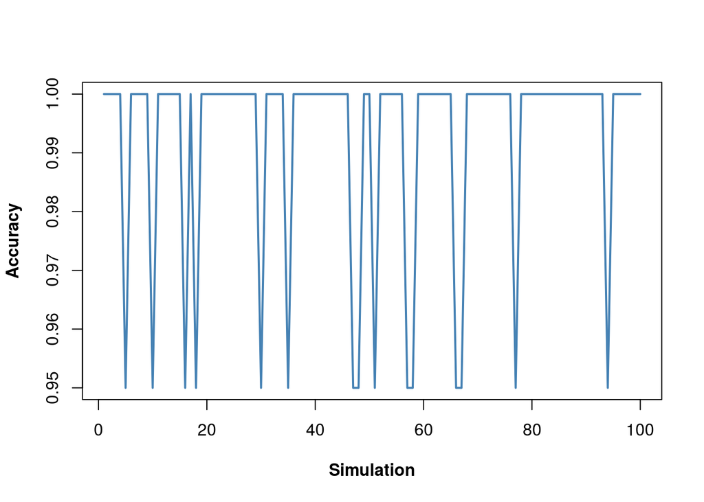

```r
## evaluation of random forest accuracy variation

## sampling from test set
total <- 1:nrow(train.stand)
test <- total[!total %in% train]

## performing 100 simulations
nsims <- 100
accuracy <- numeric(nsims)
for (i in 1:nsims) {
        test20 <- sample(test,20)
        forest.predict <- predict(forest,newdata=train.stand[test20,])
        accuracy[i] <- confusionMatrix(forest.predict,train.stand$classe[test20])$overall[1]
}

plot(accuracy,type="l",col="steelblue",font.lab=2,lwd=2,
     xlab = "Simulation",ylab = "Accuracy")
```

The mean accuracy value was 0.9925 while the standard deviation was 0.0179435 which suggest it will have good performance for the validation set. Since Random Forest has good accuracy values no need for more complex stacking techniques are need and hence the simple Random Forest constructed so far was chose as the final model.